# Индивидуальный проект этап №6

Дисциплина “Операционные системы”

Обрезкова А.В.

Российский университет дружбы народов, Москва, Россия

ФФМиЕН

27 мая 2023

# Информация

## Докладчик

- Обрезкова Анастасия Владимировна
- студентка направления “Математика и механика”
- Российский университет дружбы народов
- 1132226505@pfur.ru

# Вводная часть

## Цель работы

- РЗакончить оформление сайта, приобрести новые навыки по созданию сайта, сделать поддержку двух языков.

## Задачи

- Сделать поддержку английского и русского языков.
- Разместить элементы сайта на обоих языках.
- Разместить контент на обоих языках.
- Сделать пост по прошедшей неделе.
- Добавить пост на тему по выбору (на двух языках).

# Основная часть

- Я действовала по алгоритму, который есть на сайте [https://wowchemy.com/docs/getting-started/page-builder/#icons]. Сначала создала папку i18n и создала там два файл ru.yaml и en.ymal. Затем, разместила там скрипты для русского и английского языка.

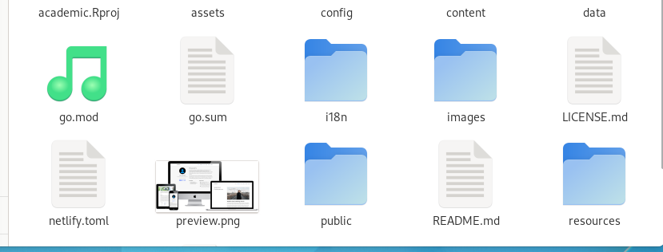

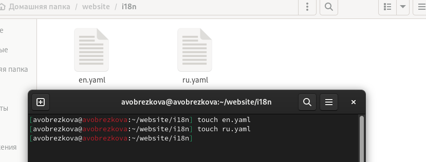

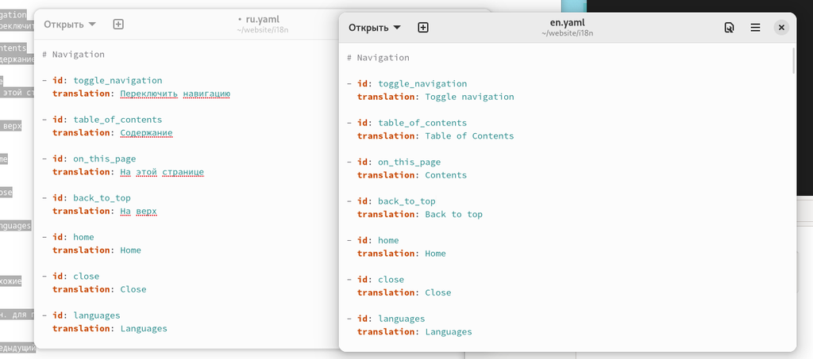

- Для удобства создаю в папке *content* две папки, в которых будут храниться все файлы на разных языках.

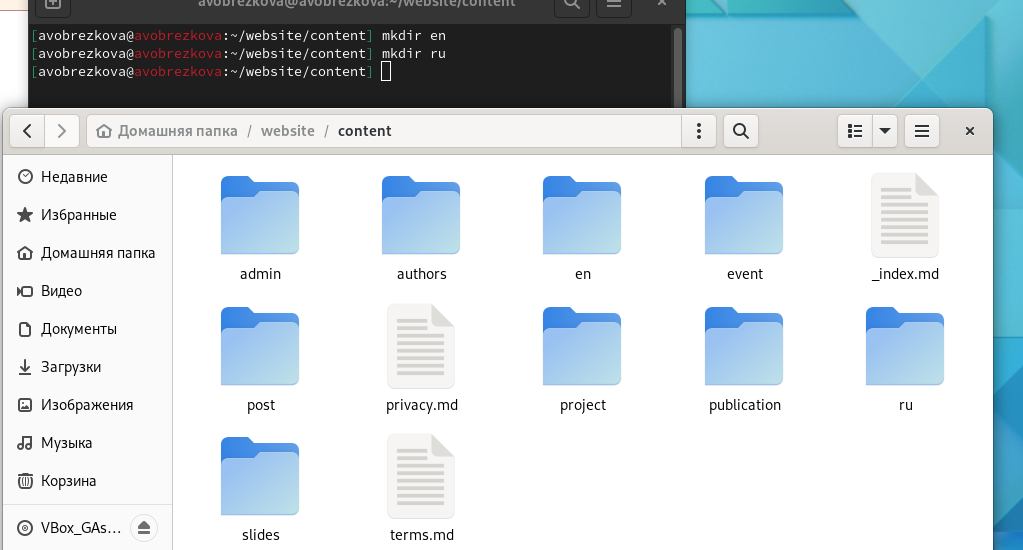

- Затем в папке config -> _default -> languages добавляем русский язык. Проверяем изменения на сайте

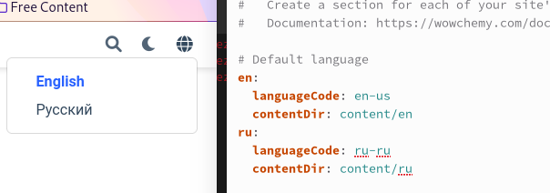

- Далее делаем перевод всех постов и информации. Вот примеры некоторых.

[figure not shown]

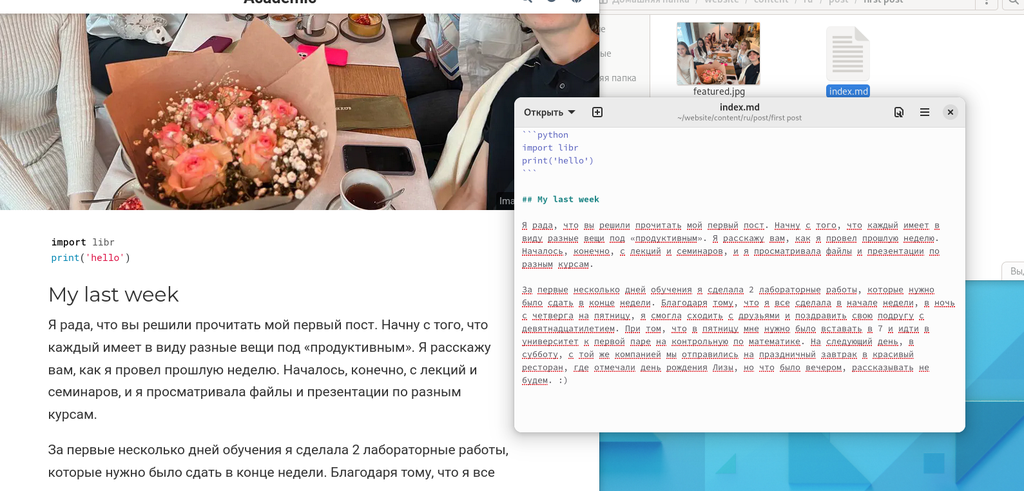

- Для перевода меню в папке config делаем новый документ с русским языком

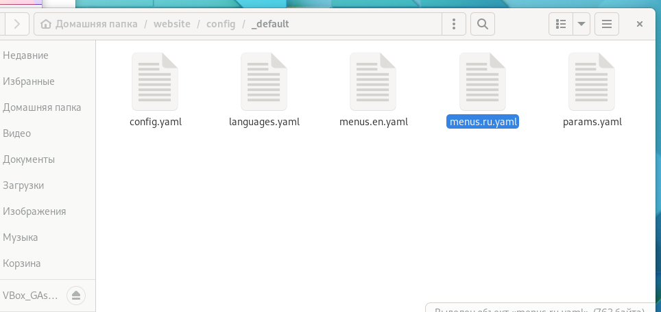

[figure not shown]

- Сделаем пост недели и пост по теме. Также переведём их на другой язык.

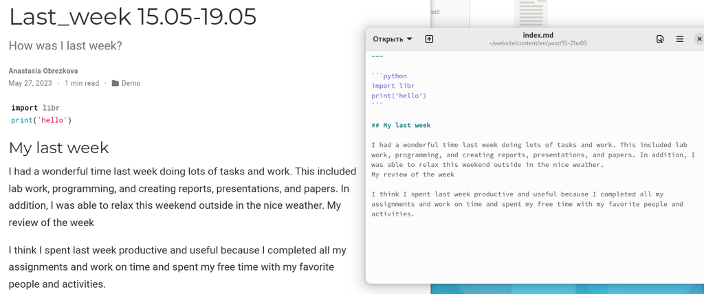

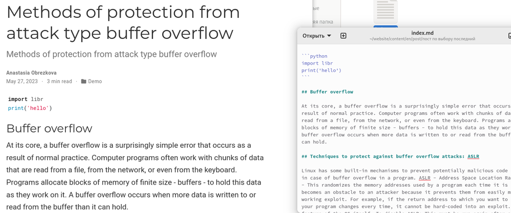

# Заключение

## Вывод

В процессе выполнения я приобрела практические навыки по созданию сайта, закончила создание сайта.